# SQL for R via SQLDF

Roberto Romo

10/27/2017

## Introduction

In this course we have learned how to manipulate, tidy, and query data via matrices, vectors, lists, and data frames. With vectors we can subscript with bracket notation to query data. Similarly, by using the “dplyr” package we can query and manipulate data frames. R is a powerful language and like many other languages benefits from libraries (packages). Packages simplify calculations (with elegance) and extend the flexibility of our programs while abstracting junky and lengthy calculations. They also allow us to personalize our working environment, one that we may be comfortable with and as a result be more efficient with.

Amongst the myriad of languages, a developer has a tough choice in selecting a tool that best fits their need. While one language may offer more flexibility another might provide efficiency. A developer first keeps a couple of languages in mind that best fits their need, but how to they then proceed and and pick one? It is key that a developer is flexible and can adapt to different working environments, however; developers find comfort in working environments and tools that are more native and natural to them. One language might have a slight edge over another but this doesn’t mean the developer should tend to the “better” one. Often, the developer tends to the one they are more comfortable with and the one that has the necessary and sufficient power to carry out the tasks.

Some packages give developers the best of both worlds; they allow a developer to use a language that they are comfortable with while using the utility of another. This post is about extending R to use SQL commands via the [“sqldf” package](https://github.com/ggrothendieck/sqldf#example-4-join) to manipulate and query data frames. Although this post will draw many parallels to the “dplyr” package, it will not compare both packages hand in hand, but rather inform of a tool that you might prefer. So let’s get started!

## Introduction to SQL

What is SQL? SQL, Structured Query Language, is a programming language that is used to manage [relational databases](https://docs.oracle.com/javase/tutorial/jdbc/overview/database.html) and to perform operations on data. SQL allows the user to forgo indices to access a record and allows the user to access many records with a single command. The fundamental utility of SQL is the ability to query and manage database systems with minimal effort.

For simplification we will only focus on the querying part of SQL and abstract the database management. We will be using the following reference as we learn more about SQL and it’s place in R.

[figure not shown]

For more comprehensive SQL tutorials the following sources might come of help: https://www.w3schools.com/sql/, https://www.tutorialspoint.com/sql/. When querying data with SQL we want to think of the data as being stored in different tables (much like a data frame), in the following sections we will learn how to query data by leveraging these column names and types.

## The Thrift Store

Not super important for our purposes but here is how our tables were created in SQL:

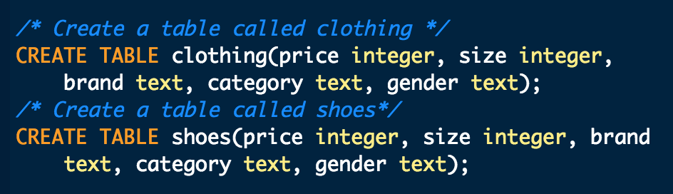

and here is how our inventory is updated:

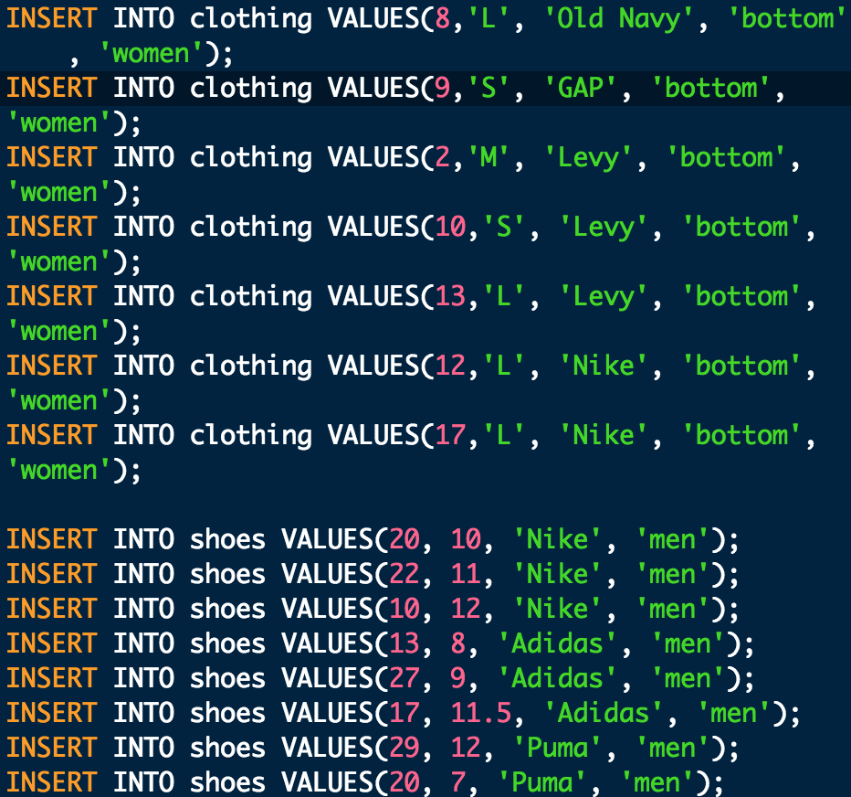